# Exploration

# 1 Introduction

This document will be used to explore our mortality data from 2007-2023, using the mortality statistics from CDC Wonder and population statistics from DOF. We will also compare the results from 2007-2023 to the earlier statistics from 1999-2006 to evaluate what has changed over time. All cleaned datasets can be found in the `/CleanData` directory, which were previously generated in the `Scripts/Cleaning.Rmd` file.

# 2 Replicating tables and figures

## 2.1 2007-2023 data

To start, I am going to exclude the data from 2023, as we will need to figure out whether we are going to make two separate tables (standardizing to 2010 and 2020 population, with understanding that years after 2020 come from population *projections*, not estimates) or just include 2006-2020 data.

### 2.1.1 Table 1

To replicate the table, we need to:

1. subset deaths to males 15-24, years 2007-2020
2. create a population weighting variable for 2000 to standardize age-adjustments
3. compute age-specific weights
4. Join weights to calculate age-adjusted rates
5. Calculate 95% CIs using log normal approximation to the Poisson distribution

Table 1. Annual mortality rates (95% CI) per 100,000 by cause of death and race/ethnic group. California males age 15–24 years, 2007–2020.

| cod | black | hispanic | white |
| --- | --- | --- | --- |
| Homicide | 93.3 (89.6–97.3) | 23.6 (22.9–24.3) | 4.4 (4.1–4.8) |
| Motor Vehicle Crashes | 18.5 (16.9–20.3) | 19.0 (18.4–19.7) | 17.6 (16.9–18.4) |
| Suicide | 10.2 (9.0–11.6) | 10.0 (9.6–10.5) | 17.0 (16.3–17.8) |
| Other Injuries | 15.5 (14.0–17.2) | 11.8 (11.3–12.3) | 21.8 (21.0–22.7) |
| Other Disease | 31.8 (29.6–34.1) | 17.8 (17.2–18.5) | 18.0 (17.2–18.7) |
| Total (All Causes) | 182.1 (176.8–187.6) | 80.5 (79.2–81.8) | 82.7 (81.1–84.4) |

### 2.1.2 Figures

We are going to use some of the functions defined in our functions.R script to conduct our exploration.

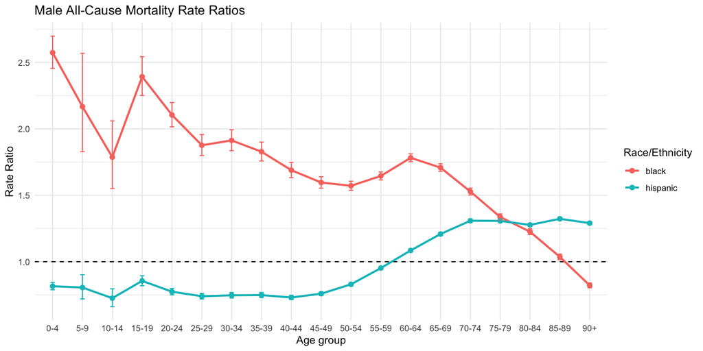

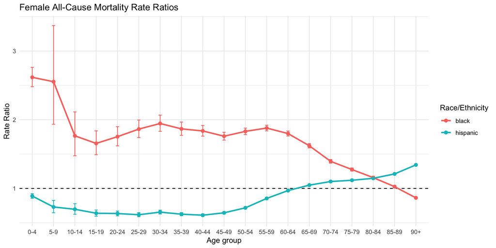

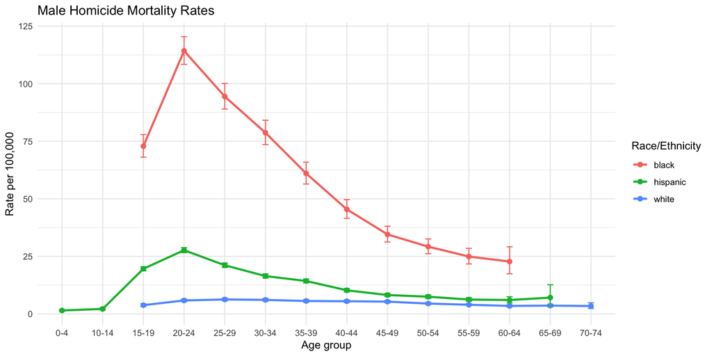

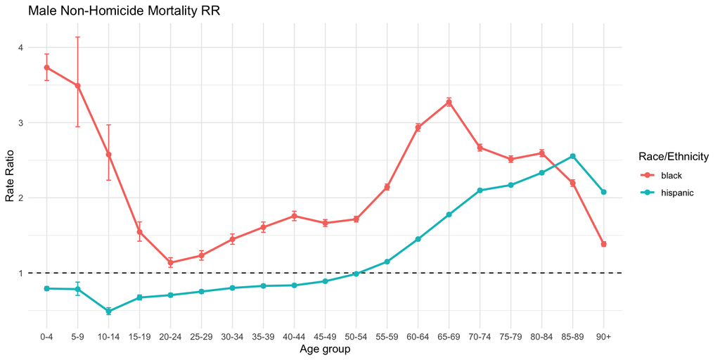

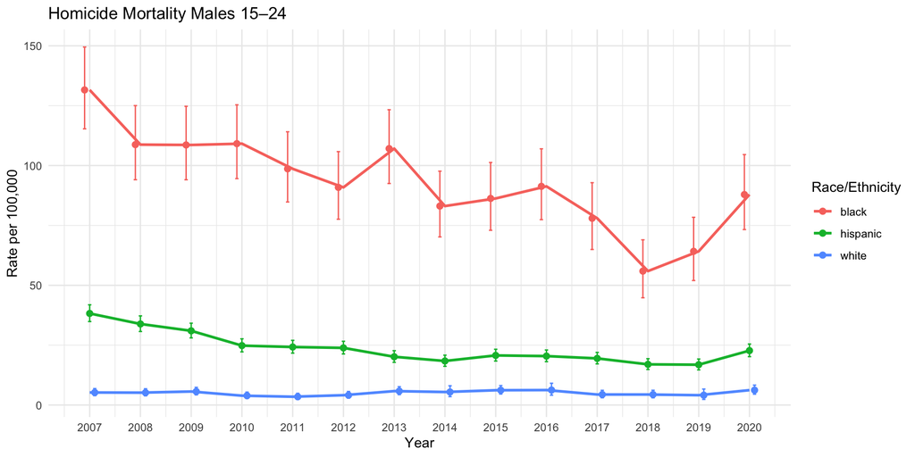

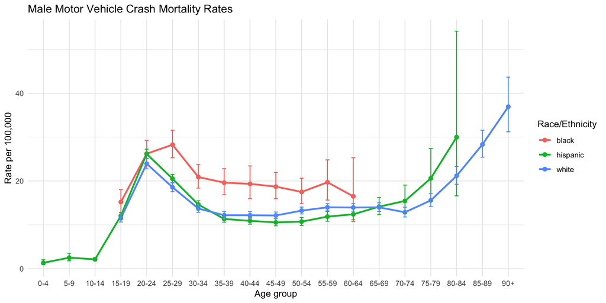

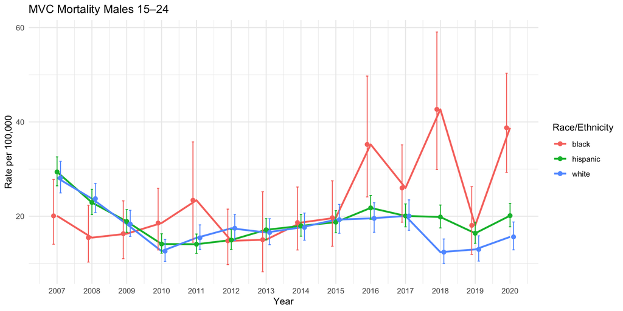

## 2.2 Comparison of 1999-2006 and 2007-2023

We will start by comparing Figure 1 (All-Cause mortality Rate Ratios comparing black/hispanic males to white males, each age group).

### 2.2.1 Figure 1: All-Casue RRs Black and Hispanic Males to White

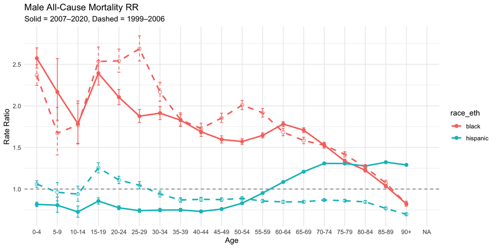

Let’s review the absolute difference in RR:

**Click to expand table**

```
## # A tibble: 38 × 3
## # Groups:   race_eth, age_group [38]
##    race_eth age_group     diff
##    <chr>    <ord>        <dbl>
##  1 black    0-4        0.206
##  2 black    10-14      0.0170
##  3 black    15-19     -0.142
##  4 black    20-24     -0.436
##  5 black    25-29     -0.811
##  6 black    30-34     -0.254
##  7 black    35-39     -0.00550
##  8 black    40-44     -0.0389
##  9 black    45-49     -0.258
## 10 black    5-9        0.494
## # ℹ 28 more rows
```

The percent change in RR:

**Click to expand table**

```
## # A tibble: 38 × 3
## # Groups:   race_eth, age_group [38]
##    race_eth age_group pct_change
##    <chr>    <ord>          <dbl>
##  1 black    0-4            8.70
##  2 black    10-14          0.962
##  3 black    15-19         -5.61
##  4 black    20-24        -17.2
##  5 black    25-29        -30.2
##  6 black    30-34        -11.7
##  7 black    35-39         -0.300
##  8 black    40-44         -2.25
##  9 black    45-49        -13.9
## 10 black    5-9           29.5
## # ℹ 28 more rows
```

**The Ratio of RRs:**

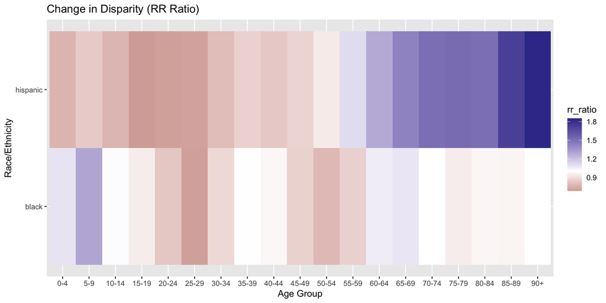

### 2.2.2 Figure 2: All-Casue RRs Black and Hispanic Females to White

Now let’s examine females instead of males:

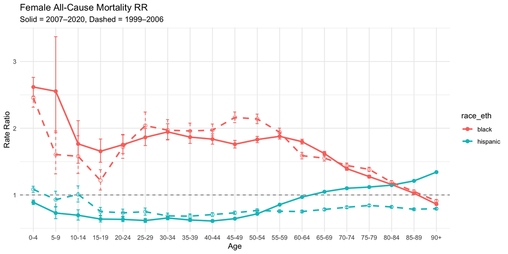

Let’s review the absolute difference in RR:

**Click to expand table**

```
## # A tibble: 38 × 3
## # Groups:   race_eth, age_group [38]
##    race_eth age_group    diff
##    <chr>    <ord>       <dbl>
##  1 black    0-4        0.163
##  2 black    10-14      0.187
##  3 black    15-19      0.438
##  4 black    20-24      0.0345
##  5 black    25-29     -0.176
##  6 black    30-34     -0.0258
##  7 black    35-39     -0.0920
##  8 black    40-44     -0.135
##  9 black    45-49     -0.402
## 10 black    5-9        0.948
## # ℹ 28 more rows
```

The percent change in RR:

**Click to expand table**

```
## # A tibble: 38 × 3
## # Groups:   race_eth, age_group [38]
##    race_eth age_group pct_change
##    <chr>    <ord>          <dbl>
##  1 black    0-4             6.63
##  2 black    10-14          11.8
##  3 black    15-19          36.0
##  4 black    20-24           2.01
##  5 black    25-29          -8.62
##  6 black    30-34          -1.31
##  7 black    35-39          -4.70
##  8 black    40-44          -6.84
##  9 black    45-49         -18.6
## 10 black    5-9            59.0
## # ℹ 28 more rows
```

**The Ratio of RRs:**

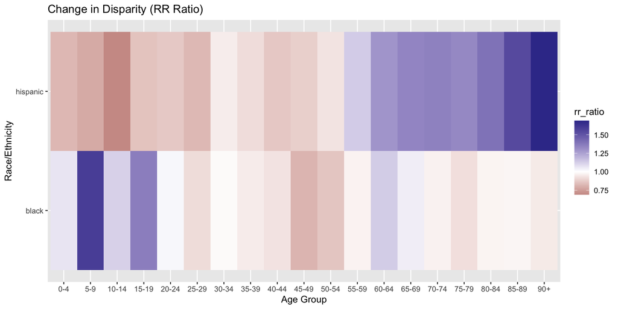

It appears that the groups to pay the most attention to are Hispanic female youths, in particular ages 10-14.

### 2.2.3 Figure 3: Male Homicide Mortality Rates

Next we will plot the mortality rates among males for homicide only.

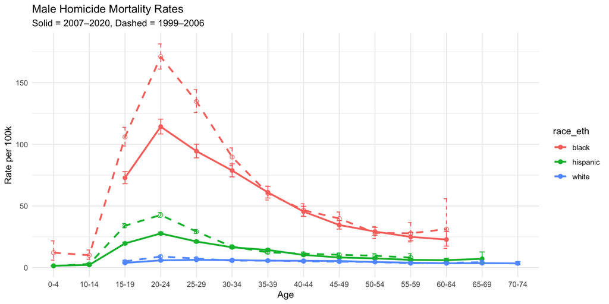

Let’s compare the rates:

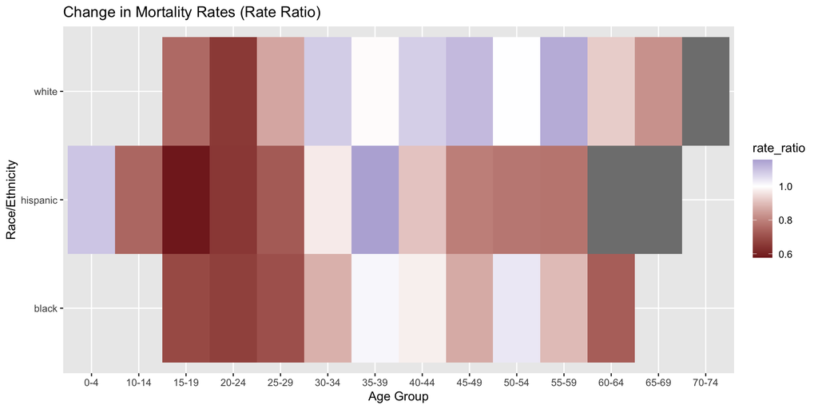

### 2.2.4 Figure 4: Male mortality rate ratios for all causes except homicide, comparing Black/Hispanic mortality to White mortality

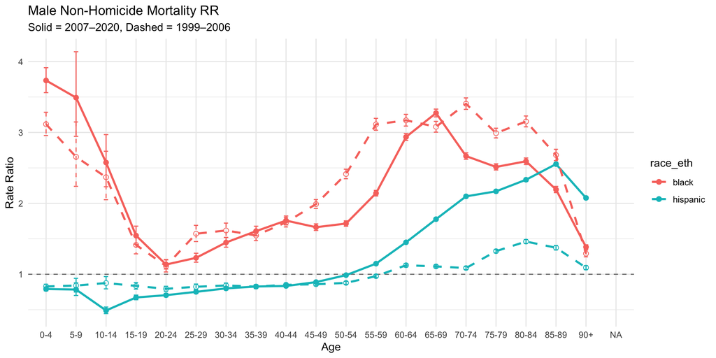

Let’s compare the rate ratios:

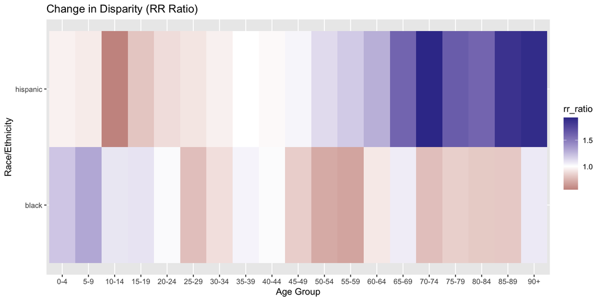

### 2.2.5 Figure 5: Homicide mortality rates, among males 15-24 years, comparing Hispanic, Black, and White mortality by year

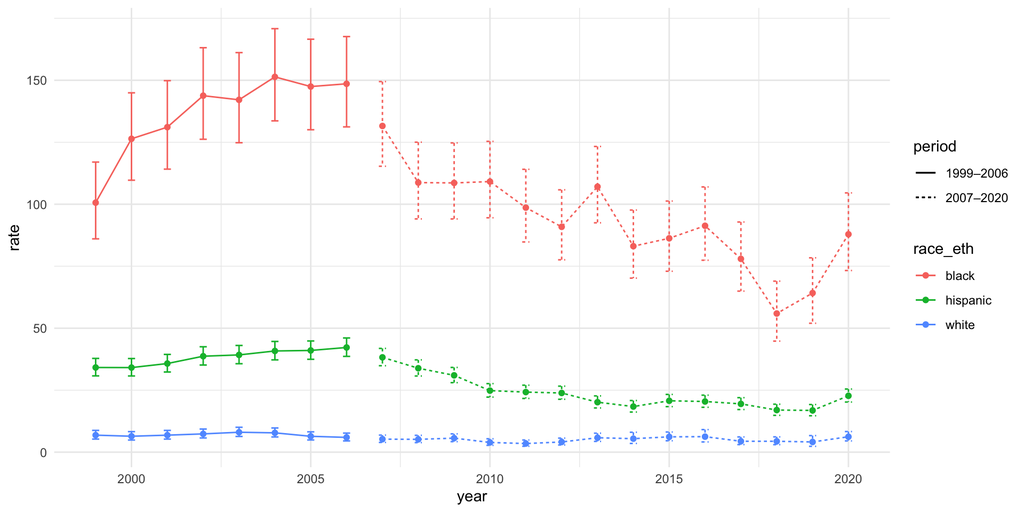

### 2.2.6 Figure 6: Male motor vehicle crash mortality rates, comparing Hispanic, Black, and Whites, 5-year age groups

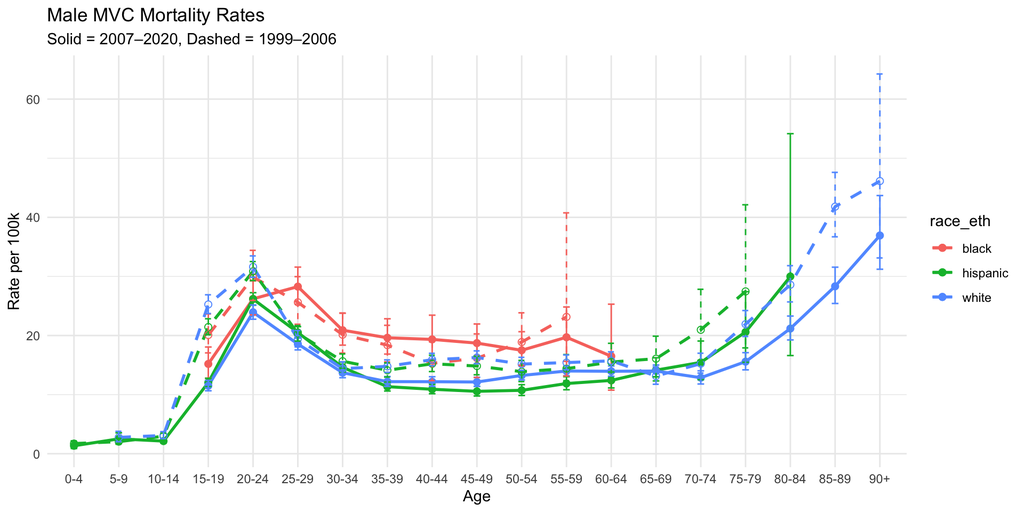

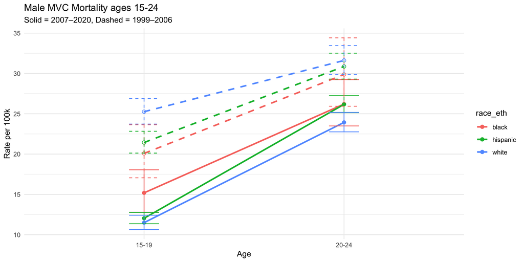

It looks as though all of them are lower! Significant differences for 15-19 y/olds that are white and hispanic.

Let’s compare the rates between all ages:

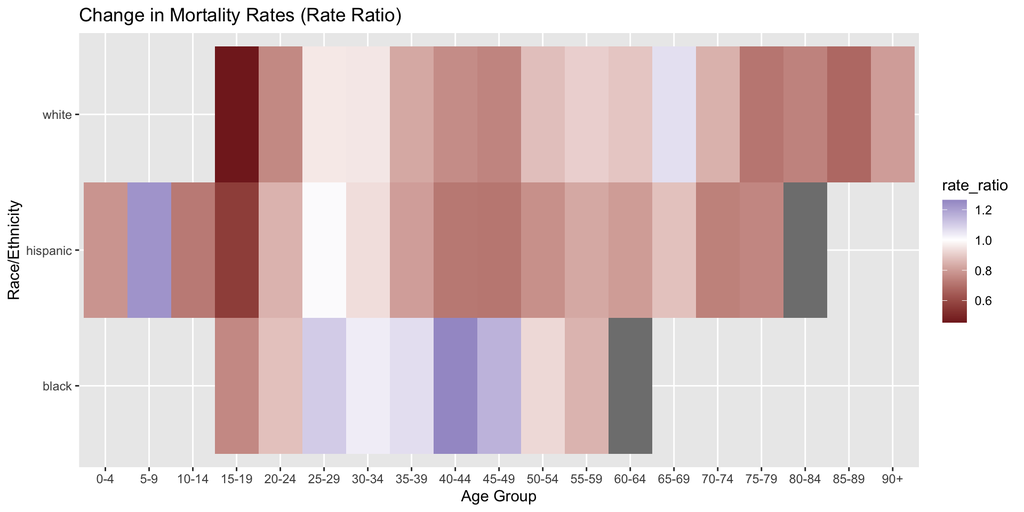

### 2.2.7 Figure 7: Motor vehicle crash mortality rates, among males 15-24 years of age

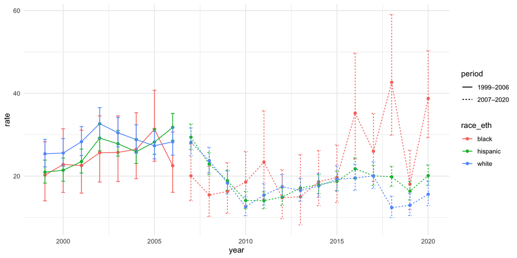